# Valuable Customer NOT Frequent Buyer

## by (Yasser Ahmed Soliman)

#### Investigation Overview

Valuable customers are the profitable ones and not the frequent buyers. From this prespective, I will investigate the database of superstore customers to correlate customer profit vs. other customer characterestics: Sales value, number of Orders, Customer Segment, Shipping mode.

## Dataset Overview

I have 51,290 customers' records with 24 features. The features type are (string, integer, float). The csv file uses (Unicode) which is different character encodings than ASCII.

## Dataset Wrangling

```python
# import all packages and set plots to be embedded inline
import numpy as np
import pandas as pd
import matplotlib.pyplot as plt
import seaborn as sb

!pip install termcolor
from termcolor import colored

#install and import wordcloud
!pip install wordcloud
from wordcloud import WordCloud
import imageio

%matplotlib inline
```

```python
# read csv file with non-ascii character.
df = pd.read_csv('superstore_dataset2011-2015.csv', encoding = 'unicode_escape')
df.head(3)
```

|  | Row ID | Order ID | Order Date | Ship Date | Ship Mode | Customer ID | Customer Name | Segment | City | State | ... | Product ID | Category | Sub-Category | Product Name | Sales | Quantity | Discount | Profit | Shipping Cost | Order Priority |
| --- | --- | --- | --- | --- | --- | --- | --- | --- | --- | --- | --- | --- | --- | --- | --- | --- | --- | --- | --- | --- | --- |
| 0 | 42433 | AG-2011-2040 | 1/1/2011 | 6/1/2011 | Standard Class | TB-11280 | Toby Braunhardt | Consumer | Constantine | Constantine | ... | OFF-TEN-10000025 | Office Supplies | Storage | Tenex Lockers, Blue | 408.300 | 2 | 0.0 | 106.140 | 35.46 | Medium |
| 1 | 22253 | IN-2011-47883 | 1/1/2011 | 8/1/2011 | Standard Class | JH-15985 | Joseph Holt | Consumer | Wagga Wagga | New South Wales | ... | OFF-SU-10000618 | Office Supplies | Supplies | Acme Trimmer, High Speed | 120.366 | 3 | 0.1 | 36.036 | 9.72 | Medium |
| 2 | 48883 | HU-2011-1220 | 1/1/2011 | 5/1/2011 | Second Class | AT-735 | Annie Thurman | Consumer | Budapest | Budapest | ... | OFF-TEN-10001585 | Office Supplies | Storage | Tenex Box, Single Width | 66.120 | 4 | 0.0 | 29.640 | 8.17 | High |

3 rows × 24 columns

```python
print(df.shape)
print(df.info())
```

```
(51290, 24)
<class 'pandas.core.frame.DataFrame'>
RangeIndex: 51290 entries, 0 to 51289
Data columns (total 24 columns):
 #   Column          Non-Null Count  Dtype
---  ------          --------------  -----
 0   Row ID          51290 non-null  int64
 1   Order ID        51290 non-null  object
 2   Order Date      51290 non-null  object
 3   Ship Date       51290 non-null  object
 4   Ship Mode       51290 non-null  object
 5   Customer ID     51290 non-null  object
 6   Customer Name   51290 non-null  object
 7   Segment         51290 non-null  object
 8   City            51290 non-null  object
```

[output cut: 18 more lines]

```python
df.columns
```

```
Index(['Row ID', 'Order ID', 'Order Date', 'Ship Date', 'Ship Mode',
       'Customer ID', 'Customer Name', 'Segment', 'City', 'State', 'Country',
       'Postal Code', 'Market', 'Region', 'Product ID', 'Category',
       'Sub-Category', 'Product Name', 'Sales', 'Quantity', 'Discount',
       'Profit', 'Shipping Cost', 'Order Priority'],
      dtype='object')
```

```python
# Rename column labels by replacing "space" with "_")
df.columns = df.columns.str.replace(' ', '_')
df.columns
```

```
Index(['Row_ID', 'Order_ID', 'Order_Date', 'Ship_Date', 'Ship_Mode',
       'Customer_ID', 'Customer_Name', 'Segment', 'City', 'State', 'Country',
       'Postal_Code', 'Market', 'Region', 'Product_ID', 'Category',
       'Sub-Category', 'Product_Name', 'Sales', 'Quantity', 'Discount',
       'Profit', 'Shipping_Cost', 'Order_Priority'],
      dtype='object')
```

```python
#Clearly define that all prices & costs are in dollars ($)
df.rename(columns={'Price':'Price_USD','Sales':'Sales_USD', 'Profit':'Profit_USD', 'Shipping_Cost':'Ship_Cost_USD'}, inplace=True)
```

```python
# Do we have any missing data? In order to list the missing values in each column we use "isnull"
df.isnull().sum()
```

```
Row_ID                0
Order_ID              0
Order_Date            0
Ship_Date             0
Ship_Mode             0
Customer_ID           0
Customer_Name         0
Segment               0
City                  0
State                 0
Country               0
Postal_Code       41296
Market                0
Region                0
Product_ID            0
Category              0
Sub-Category          0
Product_Name          0
Sales_USD             0
Quantity              0
Discount              0
Profit_USD            0
Ship_Cost_USD         0
Order_Priority        0
dtype: int64
```

*Only Postal_Code column has missing values. However, I am ONLY interested in Country-State-City, therefore I will delete the postal_code column.*

```python
# We have 24 columns already, so removing postal code column, and Row_ID

df.drop(['Postal_Code'], axis = 1, inplace = True)
df.shape[1]
```

```
23
```

I will convert Order_Date & Ship_Date from string to datetime. Because there is a chance to have more than one string format, I will prepare a list to contain all the different date strings for further processing using the "ValueError".

```python
# Order_Date conversion from string to datetime
orderdate_str = '%d/%m/%Y'
OrderDate_Errors = []

for i in df['Order_Date']:
    try:
        pd.to_datetime(i, format = orderdate_str)
    except ValueError as error1:
        OrderDate_Errors.append(error1)


if len(OrderDate_Errors) == 0:
    print('Order_Date: Done, all converted')
else:
    print('Order_Date: It is obvious that not all formats match format {}'.format(orderdate_str))

# prepare the error list
OrderDate_Errors_list = pd.DataFrame(OrderDate_Errors)


#======================================================


# Ship_Date conversion from string to datetime
shipdate_str = '%d/%m/%Y'
ShipDate_Errors = []

for j in df['Ship_Date']:
    try:
        pd.to_datetime(j, format = shipdate_str)
    except ValueError as error2:
        ShipDate_Errors.append(error2)

if len(ShipDate_Errors) == 0:
    print('Ship_Date: Done, all converted')
else:
    print('Ship_Date: It is obvious that not all formats match format {}'.format(shipdate_str))

# prepare the error list
ShipDate_Errors_list = pd.DataFrame(ShipDate_Errors)
```

```
Order_Date: It is obvious that not all formats match format %d/%m/%Y
Ship_Date: It is obvious that not all formats match format %d/%m/%Y
```

```python
print('Order_Date:', OrderDate_Errors_list.head(), '\n')
print('Ship_Date:', ShipDate_Errors_list.head())
```

```
Order_Date:                                                    0
0  time data '13-01-2011' does not match format '...
1  time data '13-01-2011' does not match format '...
2  time data '13-01-2011' does not match format '...
3  time data '13-01-2011' does not match format '...
4  time data '13-01-2011' does not match format '...

Ship_Date:                                                    0
0  time data '13-01-2011' does not match format '...
1  time data '13-01-2011' does not match format '...
2  time data '13-01-2011' does not match format '...
3  time data '13-06-2011' does not match format '...
4  time data '13-07-2011' does not match format '...
```

```python
df.dtypes[1:3]
```

```
Order_ID      object
Order_Date    object
dtype: object
```

```python
#Changing the date string format in order to have one string format ONLY

df['Order_Date'] = df['Order_Date'].str.replace('-', '/')
df['Ship_Date'] = df['Ship_Date'].str.replace('-', '/')

# Converting date string format to datetime format
df['Order_Date'] = pd.to_datetime(df['Order_Date'], format = orderdate_str)
df['Ship_Date'] = pd.to_datetime(df['Ship_Date'], format = shipdate_str)
```

```python
df.dtypes[1:3]
```

```
Order_ID              object
Order_Date    datetime64[ns]
dtype: object
```

```python
# Checking for duplicated rows

sum(df.duplicated())
```

```
0
```

Because our features of interest "Sales, Profit, Ship_Mode, Segment....", will be deeply investigated, further processing on date is required

```python
# adding year & month columns

df['Order_Year'] = df['Order_Date'].dt.year
df['Order_Month'] = df['Order_Date'].dt.month
year = df['Order_Year']
month = df['Order_Month']
df.drop(['Order_Year'], axis=1,inplace = True)
df.drop(['Order_Month'], axis=1,inplace = True)
df.insert(loc = 1, column='Order_Year', value = year)
df.insert(loc = 2, column='Order_Month', value = month)
df.head(3)
```

|  | Row_ID | Order_Year | Order_Month | Order_ID | Order_Date | Ship_Date | Ship_Mode | Customer_ID | Customer_Name | Segment | ... | Product_ID | Category | Sub-Category | Product_Name | Sales_USD | Quantity | Discount | Profit_USD | Ship_Cost_USD | Order_Priority |
| --- | --- | --- | --- | --- | --- | --- | --- | --- | --- | --- | --- | --- | --- | --- | --- | --- | --- | --- | --- | --- | --- |
| 0 | 42433 | 2011 | 1 | AG-2011-2040 | 2011-01-01 | 2011-01-06 | Standard Class | TB-11280 | Toby Braunhardt | Consumer | ... | OFF-TEN-10000025 | Office Supplies | Storage | Tenex Lockers, Blue | 408.300 | 2 | 0.0 | 106.140 | 35.46 | Medium |
| 1 | 22253 | 2011 | 1 | IN-2011-47883 | 2011-01-01 | 2011-01-08 | Standard Class | JH-15985 | Joseph Holt | Consumer | ... | OFF-SU-10000618 | Office Supplies | Supplies | Acme Trimmer, High Speed | 120.366 | 3 | 0.1 | 36.036 | 9.72 | Medium |
| 2 | 48883 | 2011 | 1 | HU-2011-1220 | 2011-01-01 | 2011-01-05 | Second Class | AT-735 | Annie Thurman | Consumer | ... | OFF-TEN-10001585 | Office Supplies | Storage | Tenex Box, Single Width | 66.120 | 4 | 0.0 | 29.640 | 8.17 | High |

3 rows × 25 columns

```python
#Creating new column (WaitingTime) which is the time difference between Order_Date & Ship_Date

df['WaitTime_Days'] = (df['Ship_Date'] - df['Order_Date']).dt.days
```

```python
# Reorder the "WaitTime_Days" column to be in 3rd index

WT = df['WaitTime_Days']
df.drop(['WaitTime_Days'], axis=1,inplace = True)
df.insert(loc = 4, column='WaitTime_Days', value = WT)
df.head(3)
```

|  | Row_ID | Order_Year | Order_Month | Order_ID | WaitTime_Days | Order_Date | Ship_Date | Ship_Mode | Customer_ID | Customer_Name | ... | Product_ID | Category | Sub-Category | Product_Name | Sales_USD | Quantity | Discount | Profit_USD | Ship_Cost_USD | Order_Priority |
| --- | --- | --- | --- | --- | --- | --- | --- | --- | --- | --- | --- | --- | --- | --- | --- | --- | --- | --- | --- | --- | --- |
| 0 | 42433 | 2011 | 1 | AG-2011-2040 | 5 | 2011-01-01 | 2011-01-06 | Standard Class | TB-11280 | Toby Braunhardt | ... | OFF-TEN-10000025 | Office Supplies | Storage | Tenex Lockers, Blue | 408.300 | 2 | 0.0 | 106.140 | 35.46 | Medium |
| 1 | 22253 | 2011 | 1 | IN-2011-47883 | 7 | 2011-01-01 | 2011-01-08 | Standard Class | JH-15985 | Joseph Holt | ... | OFF-SU-10000618 | Office Supplies | Supplies | Acme Trimmer, High Speed | 120.366 | 3 | 0.1 | 36.036 | 9.72 | Medium |
| 2 | 48883 | 2011 | 1 | HU-2011-1220 | 4 | 2011-01-01 | 2011-01-05 | Second Class | AT-735 | Annie Thurman | ... | OFF-TEN-10001585 | Office Supplies | Storage | Tenex Box, Single Width | 66.120 | 4 | 0.0 | 29.640 | 8.17 | High |

3 rows × 26 columns

```python
# Describing df data

pd.DataFrame(df.describe())
```

|  | Row_ID | Order_Year | Order_Month | WaitTime_Days | Sales_USD | Quantity | Discount | Profit_USD | Ship_Cost_USD |
| --- | --- | --- | --- | --- | --- | --- | --- | --- | --- |
| count | 51290.00000 | 51290.000000 | 51290.000000 | 51290.000000 | 51290.000000 | 51290.000000 | 51290.000000 | 51290.000000 | 51290.000000 |
| mean | 25645.50000 | 2012.777208 | 7.522636 | 3.969370 | 246.490581 | 3.476545 | 0.142908 | 28.610982 | 26.375915 |
| std | 14806.29199 | 1.098931 | 3.300056 | 1.729437 | 487.565361 | 2.278766 | 0.212280 | 174.340972 | 57.296804 |
| min | 1.00000 | 2011.000000 | 1.000000 | 0.000000 | 0.444000 | 1.000000 | 0.000000 | -6599.978000 | 0.000000 |
| 25% | 12823.25000 | 2012.000000 | 5.000000 | 3.000000 | 30.758625 | 2.000000 | 0.000000 | 0.000000 | 2.610000 |
| 50% | 25645.50000 | 2013.000000 | 8.000000 | 4.000000 | 85.053000 | 3.000000 | 0.000000 | 9.240000 | 7.790000 |
| 75% | 38467.75000 | 2014.000000 | 10.000000 | 5.000000 | 251.053200 | 5.000000 | 0.200000 | 36.810000 | 24.450000 |
| max | 51290.00000 | 2014.000000 | 12.000000 | 7.000000 | 22638.480000 | 14.000000 | 0.850000 | 8399.976000 | 933.570000 |

Data looks fine. For the Profit_USD, it is possible to have min. value with negative which means loss in some sales (sales price less than the cost).

### What is the structure of your dataset?

We have 51,290 customers' records with 24 features (as stated above in "df.columns"). Features types are (string, integer, float). The csv file uses (Unicode) which is different character encodings than ASCII.

The dataset has gone through wrangling process: Renaming column lables, checking missing data (isnull), checking for duplication (duplicated), converting date string into datetime, split year, month (with drop, insert), create new column for datat sanity check and for other purposes (Ship_Date - Order_Date)

### What is/are the main feature(s) of interest in your dataset?

I am trying to figure out the correlation between profitable customer (valuable customer) with number of ordered items, sales value, customer segmentation, customer shipping mode. Moreover, I would like to apply hypothesis test on one of the feature that I explored using A/B test.

### What features in the dataset do you think will help support your investigation into your feature(s) of interest?

I believe that customer "Customer_ID", customer segmentation "Segment", shipping mode "Ship_Mode", customer sales "Sales", and number of orders for each customer have strong correlation with customer profitability "Profit". In addition, I guess that customer frequency of orders can lead to an insightfull information towards other features.

## Customer Sales

```python
df_customer = df.groupby(['Customer_ID']).sum()
df_customer.head(3)
```

| Customer_ID | Row_ID | Order_Year | Order_Month | WaitTime_Days | Sales_USD | Quantity | Discount | Profit_USD | Ship_Cost_USD |
| --- | --- | --- | --- | --- | --- | --- | --- | --- | --- |
| AA-10315 | 902658 | 84537 | 307 | 159 | 13747.41300 | 145 | 4.350 | 447.69050 | 1236.15 |
| AA-10375 | 900216 | 84544 | 363 | 147 | 5884.19500 | 139 | 7.000 | 677.47740 | 903.92 |
| AA-10480 | 798007 | 76481 | 280 | 167 | 17695.58978 | 150 | 2.982 | 1516.47518 | 1633.67 |

Customers' sales transactions varies significantly from one customer to another. A plot for total sales value for 1,590 customers grouped in number of bins based on sales value range. The accumulated sales is based on four years 2011 - 2014. Sales distribution looks like a faded sine wave. It starts with high number of small sales value then goes down ,up and down.

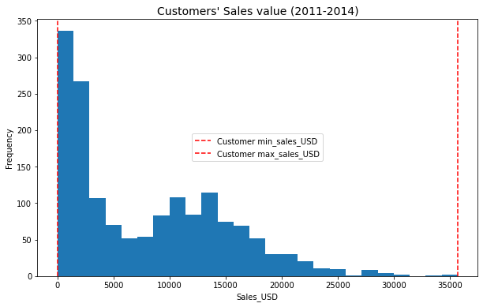

```python
plt.figure(figsize=(10,6))
bins = 25
plt.hist(df_customer.Sales_USD, bins = bins)
plt.axvline(x = min(df_customer.Sales_USD), color = 'red', linestyle ='dashed', label = 'Customer min_sales_USD')
plt.axvline(x = max(df_customer.Sales_USD), color = 'red', linestyle ='dashed', label = 'Customer max_sales_USD')

# set x/y labels and plot title
plt.xlabel("Sales_USD")
plt.ylabel("Frequency")
plt.title("Customers' Sales value (2011-2014)", fontsize=14)
plt.legend(fontsize=10, loc='center');

#min(df_customer.Sales_USD), max(df_customer.Sales_USD)
```

It is obvious that the histogram has long tail with customer sales upto 35k USD over four years

```python
df_customer['Sales_USD'].describe()
```

```
count     1590.000000
mean      7951.259063
std       6936.570172
min          7.173000
25%       1674.812250
50%       6248.135590
75%      13133.098420
max      35668.120800
Name: Sales_USD, dtype: float64
```

```python
print(df_customer['Sales_USD'].describe()[4]) # Q1
print(df_customer['Sales_USD'].describe()[6]) # Q3
```

```
1674.81225
13133.098419999998
```

```python
# Filtering Sales Outliers

IQR1 = (df_customer['Sales_USD'].describe()[6] - df_customer['Sales_USD'].describe()[4])  # IQR1 = Q3 - Q1
Outlier1_s = (df_customer['Sales_USD'].describe()[6] + 1.5*IQR1)  # outlier

df_Sales_RemOut = df_customer[df_customer['Sales_USD'] < Outlier1_s]

Outlier1_s
```

```
30320.527674999998
```

## Profit (Customer Value)

The profit distribution from customers' sales does not follow the same sales ditribution. This means that profit on sales transaction is not constant. As a matter of fact we have customers causing losses despite of their sales transactions over four years.

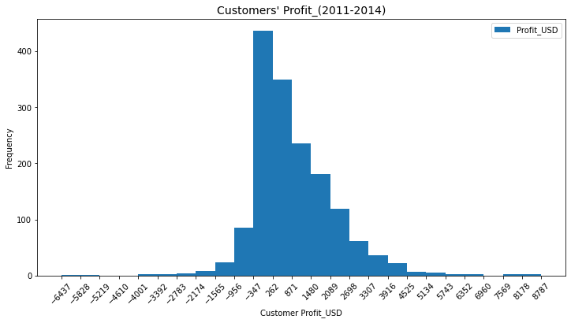

```python
#bin size = 25
count, bin_edges = np.histogram(df_customer['Profit_USD'],25)

df_customer['Profit_USD'].plot(kind='hist',
                               figsize=(12,6),
                               bins=25,
                               xticks=bin_edges,
                               rot = 45
                              )


plt.xlabel("Customer Profit_USD")
plt.title("Customers' Profit_(2011-2014)", fontsize=14)
plt.legend()
plt.show()
```

Not all customers' sales are profitable as there are some sales with loss.

```python
df_customer.Profit_USD.describe()
```

```
count    1590.000000
mean      922.929114
std      1328.397668
min     -6437.368100
25%        94.812000
50%       591.357100
75%      1614.486975
max      8787.474900
Name: Profit_USD, dtype: float64
```

```python
print(df_customer['Profit_USD'].describe()[4]) # Q1
print(df_customer['Profit_USD'].describe()[6]) # Q3
```

```
94.812
1614.4869749999998
```

```python
# Filtering Profit Outliers

IQR2 = (df_customer['Profit_USD'].describe()[6] - df_customer['Profit_USD'].describe()[4])  # IQR2 = Q3 - Q1
Outlier2_p = (df_customer['Profit_USD'].describe()[6] + 1.5*IQR2)  # outlier

df_Profit_RemOut = df_customer[df_customer['Profit_USD'] < Outlier2_p]
Outlier2_p
```

```
3893.9994374999997
```

## Customer Segments

#### What are the different segments? What is the number of customers in each segment?

|  | Customers |
| --- | --- |
| Consumer | 818 |
| Corporate | 476 |
| Home Office | 296 |

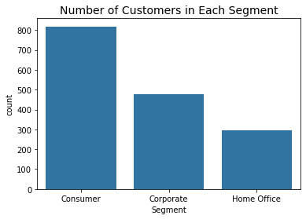

```python
#Grouping customers by "Customer_ID", and defining the segment type by taking the first row of each group
df_Segment = df[['Customer_ID','Segment']].groupby(['Customer_ID']).first()

#Counting number of customers in each segment
segment_count = df_Segment.Segment.value_counts()
segment_count = segment_count.index

#Plotting the different segments
base_color = sb.color_palette()[0]
sb.countplot(data=df_Segment, x='Segment', color = base_color, order=segment_count)

plt.title("Number of Customers in Each Segment", fontsize = 14)
#Displaying the table
(pd.DataFrame(df_Segment.Segment.value_counts())).rename(columns={'Segment':'Customers'})
```

"Consumer" segment is the domenant segment among the three segments.

## Segment Profit portion from Total Profit over the 4 years

```python
# Segment vs. Sales & Profit
df_grp_seg = df[['Segment', 'Sales_USD', 'Profit_USD']].groupby(['Segment'], as_index=False).sum()
df_grp_seg = df_grp_seg.sort_values(['Profit_USD'], axis=0, ascending = False)
df_grp_seg
```

|  | Segment | Sales_USD | Profit_USD |
| --- | --- | --- | --- |
| 0 | Consumer | 6.507949e+06 | 749239.78206 |
| 1 | Corporate | 3.824698e+06 | 441208.32866 |
| 2 | Home Office | 2.309855e+06 | 277009.18056 |

| Segment | Sales_USD | Profit_USD |
| --- | --- | --- |
| Consumer | 6.507949e+06 | 749239.78206 |
| Corporate | 3.824698e+06 | 441208.32866 |
| Home Office | 2.309855e+06 | 277009.18056 |

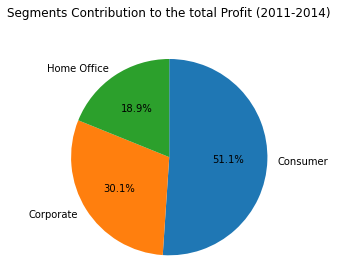

```python
plt.pie(df_grp_seg['Profit_USD'],
        labels = df_grp_seg['Segment'],
        startangle = 90,
        counterclock = False,
        autopct= '%1.1f%%'
       )


plt.title('Segments Contribution to the total Profit (2011-2014)', y=1.12)
plt.axis('square');

#Displaying the table
df_grp_seg.set_index('Segment')
```

*Consumer* segment is the most dominant one with 51.1% contribution to the total profit, then *Corporate* with 30.1%, and last *Home Office* with 18.9%.

## Shipping Mode

```python
# What is the shipping mode frequency? knowing that shipping mode is a function in Order_ID
# What is the mean waiting time for each Order_ID?

df_ShipMode = df.groupby(['Order_ID','Ship_Mode'], as_index=False).WaitTime_Days.mean()
df_ShipMode
```

|  | Order_ID | Ship_Mode | WaitTime_Days |
| --- | --- | --- | --- |
| 0 | AE-2011-9160 | Standard Class | 4.0 |
| 1 | AE-2013-1130 | Same Day | 0.0 |
| 2 | AE-2013-1530 | Second Class | 3.0 |
| 3 | AE-2014-2840 | First Class | 3.0 |
| 4 | AE-2014-3830 | Standard Class | 6.0 |
| ... | ... | ... | ... |
| 25436 | ZI-2014-7160 | First Class | 2.0 |
| 25437 | ZI-2014-7610 | Standard Class | 4.0 |
| 25438 | ZI-2014-9540 | Standard Class | 6.0 |
| 25439 | ZI-2014-9550 | Standard Class | 5.0 |
| 25440 | ZI-2014-9650 | Second Class | 2.0 |

25441 rows × 3 columns

```python
# What are the different shipping modes? What is the number of orders (Order_ID) in each shipping mode?

df1_wtime = df_ShipMode.groupby(['Ship_Mode'], as_index=True).WaitTime_Days.describe()
df1_wtime = df1_wtime.sort_values(['mean'], axis = 0, ascending = False)
print(colored('WaitingTime_Days', 'blue', attrs =['bold']))
df1_wtime
```

```
WaitingTime_Days
```

| Ship_Mode | count | mean | std | min | 25% | 50% | 75% | max |
| --- | --- | --- | --- | --- | --- | --- | --- | --- |
| Standard Class | 15154.0 | 5.003240 | 1.000304 | 4.0 | 4.0 | 5.0 | 6.0 | 7.0 |
| Second Class | 5119.0 | 3.219390 | 1.165824 | 2.0 | 2.0 | 3.0 | 4.0 | 5.0 |
| First Class | 3821.0 | 2.189437 | 0.747177 | 1.0 | 2.0 | 2.0 | 3.0 | 3.0 |
| Same Day | 1347.0 | 0.042316 | 0.201384 | 0.0 | 0.0 | 0.0 | 0.0 | 1.0 |

The frequently used shipping mode is the "Standard Class" which is around 59.6% from total orders. The standard class has a mean waiting time ~ 5 days (WaitTie = Ship_Date - Order_Date) with maximum time 7 days. All other shipping modes have lower time (mean & max). No doubt that other shippimg modes with shorter waiting time comes with higher price. Probably that is the reason that majority of orders are associated with "Standard Class", meaning less cost for the customer and just very few days more before shipping (e.g. First class has mean waiting time = 2days, while standard = 5days).

| Ship_Mode | Orders | Avg.WaitTime |
| --- | --- | --- |
| Standard Class | 15154.0 | 5.003240 |
| Second Class | 5119.0 | 3.219390 |
| First Class | 3821.0 | 2.189437 |
| Same Day | 1347.0 | 0.042316 |

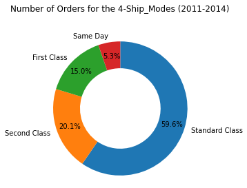

```python
# Counting number of Orders (Order_ID) for the four shipping mode

plt.pie(df1_wtime['count'],
        labels = df1_wtime.index,
        startangle = 90,
        counterclock = False,
        wedgeprops = {'width' : 0.4},
        pctdistance=0.8,
        autopct= '%1.1f%%'
       );
plt.title('Number of Orders for the 4-Ship_Modes (2011-2014)', y=1.12)
plt.axis('square')

#Displaying the table
pd.DataFrame(df1_wtime[['count','mean']]).rename(columns={'count':'Orders', 'mean':'Avg.WaitTime'})
```

The frequently used shipping mode is the "Standard Class" which is around 59.6% from total orders.

### Frequent Buyers (Customers vs. Sales' Orders)

The number of customer transactions (sales orders for each customer) is the total number of Row_IDs for that customer.

```python
#Adding new column label "Counts" to support the next calculations
df['Counts'] = 1

df_OrderID = df[['Customer_ID', 'Row_ID', 'Counts']].groupby(['Customer_ID', 'Row_ID'], as_index=False).count()
df_OrderID
```

|  | Customer_ID | Row_ID | Counts |
| --- | --- | --- | --- |
| 0 | AA-10315 | 4754 | 1 |
| 1 | AA-10315 | 7998 | 1 |
| 2 | AA-10315 | 7999 | 1 |
| 3 | AA-10315 | 8000 | 1 |
| 4 | AA-10315 | 8001 | 1 |
| ... | ... | ... | ... |
| 51285 | ZD-21925 | 35111 | 1 |
| 51286 | ZD-21925 | 35112 | 1 |
| 51287 | ZD-21925 | 37194 | 1 |
| 51288 | ZD-21925 | 37195 | 1 |
| 51289 | ZD-21925 | 39638 | 1 |

51290 rows × 3 columns

```python
#Displaying the table
ord_count = df_OrderID.groupby(['Customer_ID'])['Counts'].count()
ord_count = pd.DataFrame(ord_count).rename(columns={'Counts':'Orders'})
ord_count = ord_count.sort_values(['Orders'], axis=0, ascending = False)
print('Total Customers Orders = ', ord_count.Orders.sum(), '\n')
ord_count.head()
```

```
Total Customers Orders =  51290
```

| Customer_ID | Orders |
| --- | --- |
| PO-18850 | 97 |
| BE-11335 | 94 |
| JG-15805 | 90 |
| SW-20755 | 89 |
| EM-13960 | 85 |

```
No. of customers =  1590
```

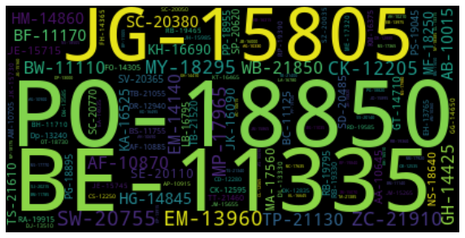

```python
#Using WordCloud to visualize the most frequent buyers (customers)

CusID_count = df_OrderID.Customer_ID.value_counts()
CusID_cloud = WordCloud().generate_from_frequencies(CusID_count)
print('No. of customers = ',CusID_count.count())

# Visualize the word cloud
fig = plt.figure()
fig.set_figwidth(10) # set width
fig.set_figheight(8) # set height
plt.imshow(CusID_cloud, interpolation='bilinear')
plt.axis('off')
plt.show()
```

From WordCloud we can feel from font size who are the top customers for the number of orders. We have "1590" customers with total order transactions of "51290". The larger the size of Customer_ID the the higher the number of orders (Transactions) this Customer_ID has.

Now, I am going to apply Pareto rule (80/20) to list the top most dominant customer for number of orders (transaction). So the 20% of customer should count for 80% of total purchase orders (according Pareto rule) over 4 years.

```python
# A list of the top 20% of frequent buyers (customer with higher number of orders) over the 4 years in descending order

y = 0.2 # the percentage for the number of customer from the top customers order

CusID_count2 = int(CusID_count.shape[0]*y)  # y is a percentage from 1590 customer.
CusID_count_top = CusID_count.head(CusID_count2)

print('Total orders (transaction) = ', df_OrderID.shape[0])
print('The orders of top Frequent-Buyers ({}% = {} customer) forms ({}%) of total unique orders (transaction).'
      .format(int(y*100),CusID_count2, int(sum(CusID_count_top)/df_OrderID.shape[0]*100)))
print('The max frequency of the top list = ', CusID_count_top.max())
print('The min frequency of the top list = ', CusID_count_top.min())
```

```
Total orders (transaction) =  51290
The orders of top Frequent-Buyers (20% = 318 customer) forms (39%) of total unique orders (transaction).
The max frequency of the top list =  97
The min frequency of the top list =  55
```

Because the top 20% forms only 39% of total orders (not 80%), Pareto rule (80/20) does not apply here. Let's have a visualize dashboard for number of orders for ONLY 2% of top frequet buyers.

```
This is a list of 31 Customers_ID which is (2.0%) of the total customers.
Max. customer's number of orders =  97
Min. customer's number of orders =  74
```

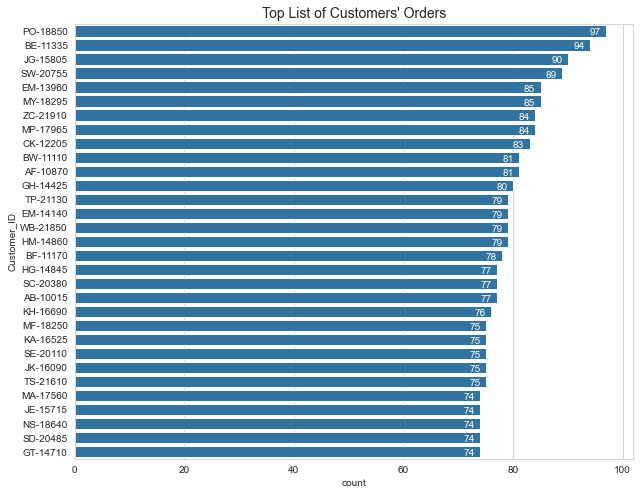

```python
# For clear list of the top 2% of frequent customers over the 4 years in descending order

y2 = 0.02 # the percentage for the number of customer from the list of top customers' order
CusID_count3 = int(CusID_count.shape[0]*y2)
CusID_count_top2 = CusID_count.head(CusID_count3)

plt.figure(figsize=(10,8))
base_color = sb.color_palette()[0]

ax = sb.countplot(data = df_OrderID, y='Customer_ID', color = base_color, order=CusID_count_top2.index)

for index, value in enumerate(CusID_count_top2):
    label = format(int(value))

    # place text at the end of bar (subtracting 47000 from x, and 0.1 from y to make it fit within the bar)
    ax.annotate(label, xy=(value-3  , index+0.3 ), color='white')



plt.title("Top List of Customers' Orders", fontsize = 14)
print('This is a list of {} Customers_ID which is ({}%) of the total customers.'.format(CusID_count3, y2*100))
print("Max. customer's number of orders = ", CusID_count_top2.max())
print("Min. customer's number of orders = ", CusID_count_top2.min())
```

The top 2% (31 customers) frequent buyers falls between (74-97) orders (transaction) over four years (2011-2014)

### Discuss the distribution(s) of your variable(s) of interest. Were there any unusual points? Did you need to perform any transformations?

I develped new column called "WaitTime_Day" which is the difference between (Ship_Date - Order_Date) for data integrity where a waiting time with negative value will lead to a deletion of this row.

## Bivariate Exploration

#### I would like to study the following relationship:

1. Shipping mode (Ship_Mode) vs. Sales value and its corresponding Profit
2. Segment vs. Sales value its corresponding Profit
3. Top customer with number of orders (transactions) vs. Top customers with sales value...Who is more profitable?
4. Studying the correlation between Average Customer Yearly Profit vs (Sales, Orders, Segment)
5. How the number of orders are split with Segment and within different shipping modes?

Observing the relationship between customer sales transaction and shipping mode category

```python
df['Sales_USD'].describe()
```

```
count    51290.000000
mean       246.490581
std        487.565361
min          0.444000
25%         30.758625
50%         85.053000
75%        251.053200
max      22638.480000
Name: Sales_USD, dtype: float64
```

```python
# Filtering Sales Outliers

IQR1 = (df['Sales_USD'].describe()[6] - df['Sales_USD'].describe()[4])  # IQR1 = Q3 - Q1
Outlier1 = (df['Sales_USD'].describe()[6] + 1.5*IQR1)  # outlier

df_Sales_RemOut = df[df['Sales_USD'] < Outlier1]
Outlier1
```

```
581.4950625
```

## Ship_Mode vs. Sales vs. Profit

It was obvious that sales distribution has long tail in the histogram, but now it is clear that all outliers are spread in the four categorical shipping mod.Because profitability is the ultimate goal for any business investment, it is also clear that the number of profitable customers (Q3) with "Standard Class" are larger than the other shipping modes. On the other hand, the largest number of customers with low profit are seen with "Second Class" shipping mode. I intentionaly overlaped the boxplot & violinplot to ignite insight.

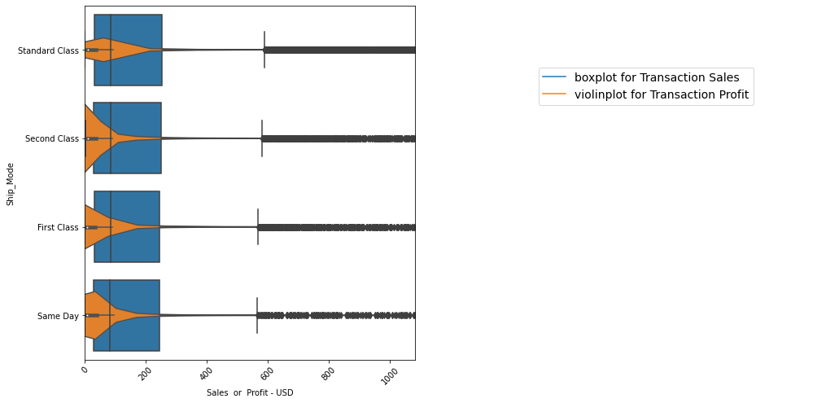

```
Sales_USD
```

| Ship_Mode | count | mean | std | min | 25% | 50% | 75% | max |
| --- | --- | --- | --- | --- | --- | --- | --- | --- |
| Second Class | 10309.0 | 248.876873 | 482.473517 | 1.161 | 30.300 | 84.50 | 250.272 | 8749.95 |
| Same Day | 2701.0 | 247.020357 | 470.230821 | 0.556 | 30.336 | 83.55 | 244.260 | 7999.98 |
| Standard Class | 30775.0 | 246.260020 | 491.894554 | 0.444 | 30.870 | 85.68 | 253.920 | 22638.48 |
| First Class | 7505.0 | 243.967507 | 482.876709 | 0.984 | 31.200 | 84.42 | 245.673 | 13999.96 |

```python
# Types of shipping mode
shipmode_class = ['Standard Class', 'Second Class', 'First Class', 'Same Day']

#Conver into an ordered categorical type
ship_cat = pd.api.types.CategoricalDtype(ordered=True, categories = shipmode_class)

df['Ship_Mode'] = df['Ship_Mode'].astype(ship_cat);
plt.figure(figsize = [16, 8])

#Figure1 : Shipping mode vs transactinal sales
plt.subplot(1, 2, 1)
ax1 = sb.boxplot(data=df, x='Sales_USD', y='Ship_Mode', color = sb.color_palette()[0])
plt.xticks(rotation=45)
plt.xlim(0,(Outlier1+500))

#igure2: Shipping mode vs transactinal profit
plt.subplot(1, 2, 1)
sb.violinplot(data=df, x='Profit_USD', y='Ship_Mode', innner='quartile', color = sb.color_palette()[1])
plt.xticks(rotation=45);
plt.xlim(ax1.get_xlim()) # set x-axis limits
plt.xlabel('Sales  or  Profit - USD')

plt.subplot(2, 2, 2)
plt.plot(0,0,label='boxplot for Transaction Sales')
plt.plot(0,0,label='violinplot for Transaction Profit')
plt.legend(fontsize=14, loc='center')
plt.gca().spines['top'].set_visible(False)
plt.gca().spines['right'].set_visible(False)
plt.gca().spines['left'].set_visible(False)
plt.gca().spines['bottom'].set_visible(False)
plt.yticks([])
plt.xticks([])
plt.show()


#Ship_Mode vs Sales
df1_shipmd = df.groupby(['Ship_Mode'], as_index=True).Sales_USD.describe()
df1_shipmd = df1_shipmd.sort_values(['mean'], axis = 0, ascending = False)
print(colored('Sales_USD', 'blue', attrs =['bold']))
df1_shipmd
```

## Segment v. Sales vs. Profit

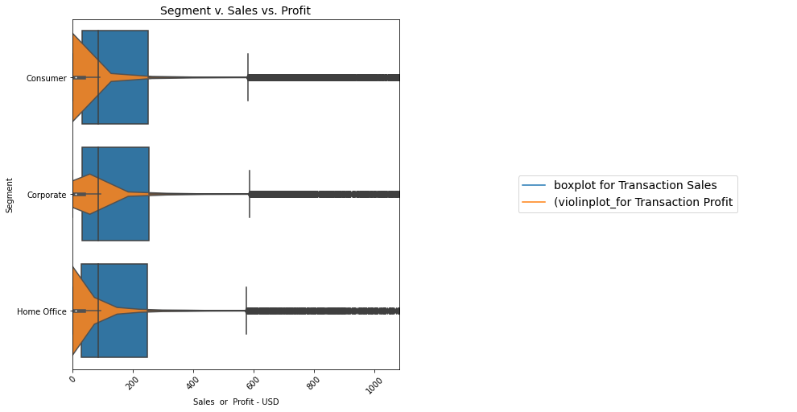

```
Profit_USD
```

| Segment | count | mean | std | min | 25% | 50% | 75% | max |
| --- | --- | --- | --- | --- | --- | --- | --- | --- |
| Home Office | 9343.0 | 29.648847 | 170.577590 | -3399.980 | 0.0 | 9.3200 | 37.0800 | 3919.9888 |
| Corporate | 15429.0 | 28.596042 | 177.156362 | -4088.376 | 0.0 | 9.3152 | 36.9450 | 8399.9760 |
| Consumer | 26518.0 | 28.254008 | 174.006045 | -6599.978 | 0.0 | 9.1800 | 36.6525 | 6719.9808 |

```python
# Types of shipping mode
segment_class = ['Consumer', 'Corporate', 'Home Office']

#Conver into an ordered categorical type
segmnt_cat = pd.api.types.CategoricalDtype(ordered=True, categories = segment_class)

df['Segment'] = df['Segment'].astype(segmnt_cat);
plt.figure(figsize = [16, 8])

#Figure: Shipping mode vs transactinal sales
plt.subplot(1, 2, 1)
ax1 = sb.boxplot(data=df, x='Sales_USD', y='Segment', color = sb.color_palette()[0])
plt.xticks(rotation=45)
plt.xlim(0,(Outlier1+500))

#Figure: Shipping mode vs transactinal profit
plt.subplot(1, 2, 1)
plt.title("Segment v. Sales vs. Profit", fontsize = 14)
sb.violinplot(data=df, x='Profit_USD', y='Segment', innner='quartile', color = sb.color_palette()[1])
plt.xticks(rotation=45);
plt.xlim(ax1.get_xlim()) # set x-axis limits
plt.xlabel('Sales  or  Profit - USD')

plt.subplot(1, 2, 2)
plt.plot(0,0,label='boxplot for Transaction Sales')
plt.plot(0,0,label='(violinplot_for Transaction Profit')
plt.legend(fontsize=14, loc='center')
plt.gca().spines['top'].set_visible(False)
plt.gca().spines['right'].set_visible(False)
plt.gca().spines['left'].set_visible(False)
plt.gca().spines['bottom'].set_visible(False)
plt.yticks([])
plt.xticks([])
plt.show()

#Ship_Mode vs Profit
df1_segmnt = df.groupby(['Segment'], as_index=True).Profit_USD.describe()
df1_segmnt = df1_segmnt.sort_values(['mean'], axis = 0, ascending = False)
print(colored('Profit_USD', 'blue', attrs =['bold']))
df1_segmnt
```

## Customer (Customer_ID)

1. Customer (Customer_ID) vs. (Profit_USD)

### I will develop two lists of top customers:

1. Top (x%) Sales Customers
2. Top (y%) Fequent Buyers (number of orders)

Where the top number of customers in the list will be defined with percentage (x&y)

**Question:** Are the top "Frequent-Buyers" more profitable than the top "Sales-Customers"?

> To answser this question we need to get the aggregated profit for each list. Also we can calculate the profit portion for each list from total profit to get better perception.

```python
print('Total No. of customers = ',CusID_count.count(), ' customers','\n')
```

```
Total No. of customers =  1590  customers
```

#### Top Sales Customers List

- Value of (x) is the portion from the total number of customers to be in the list "Top Customer Sales Value"

```python
# Creating a table of customers' sales over the 4 years, then sorting the profit in descending order

df_grp_cust = df[['Customer_ID', 'Sales_USD','Profit_USD']].groupby(['Customer_ID'], as_index=False).sum()
df_grp_cust = df_grp_cust.sort_values(['Sales_USD'], axis=0, ascending = False)
df_grp_custname = df_grp_cust.set_index('Customer_ID')



# Listing the top (x*100)% of sales customers, then aggregating the sales for this list

x = 1.0           # define the portion for the number of customer from the total customer list
df_grp_cust_lst = int(df_grp_custname.shape[0]*x)
df_grp_cust_top = df_grp_custname.head(df_grp_cust_lst)
df_grp_cust_top = pd.DataFrame(df_grp_cust_top)
top_sale_list_profit = df_grp_cust_top.Profit_USD.sum()/df_grp_cust.Profit_USD.sum()


print('Number of Customers = ', df_grp_cust_lst)
print('Total Profit (USD) = ',round(df_grp_cust.Profit_USD.sum()))
print('The aggregated profit of {}% of TOP_SALES customers is around {}% of total profit.'
      .format(x*100, int(top_sale_list_profit*100)),'\n', '\n')

print(colored('Top Customers Sales Value List', 'blue', attrs =['bold']))
df_grp_cust_top.head(3) # list of top Sales (x*100)% of total customers
```

```
Number of Customers =  1590
Total Profit (USD) =  1467457
The aggregated profit of 100.0% of TOP_SALES customers is around 100% of total profit.


Top Customers Sales Value List
```

| Customer_ID | Sales_USD | Profit_USD |
| --- | --- | --- |
| TA-21385 | 35668.12080 | 6274.98910 |
| GT-14710 | 34471.89028 | 5164.84718 |
| TC-20980 | 34218.26900 | 8787.47490 |

#### Top Frequent-Buyers List

- Value of (y3) is the portion from the total number of customers to be in the list "Top Freuest Sales Orders"

```python
# Listing the top (y3*100)% top customers for number of orders (frequent buyers).

y3 = 1.0             # the portion for the number of customer from the total list of (frequent buyers)
CusID_count4 = int(CusID_count.shape[0]*y3)
CusID_count_top3 = CusID_count.head(CusID_count4)

# Linking the top (y3*100)% frequent buyers to their profit, then aggregating the profit
df_grp_ord_cust_inv = df_grp_custname.drop(CusID_count_top3.index)
df_grp_ord_cust_prft = df_grp_custname.drop(df_grp_ord_cust_inv.index)
df_grp_ord_cust_prft = pd.DataFrame(df_grp_ord_cust_prft)
top_ord_list_profit = df_grp_ord_cust_prft.Profit_USD.sum()/df_grp_cust.Profit_USD.sum()


print('Number of Customers = ', CusID_count4)
print('Total Profit (USD) = ',round(df_grp_cust.Profit_USD.sum()))
print('The aggregated profit of {}% of TOP_FRQUENT buyers (customers) is around {}% of total profit.'
      .format(y3*100, int(top_ord_list_profit*100)),'\n', '\n')

print(colored('Top Frequent Customer Orders List', 'blue', attrs =['bold']))
df_grp_ord_cust_prft.head(3) # list of top (y3*100)% customers for number of orders (transactions)
```

```
Number of Customers =  1590
Total Profit (USD) =  1467457
The aggregated profit of 100.0% of TOP_FRQUENT buyers (customers) is around 100% of total profit.


Top Frequent Customer Orders List
```

| Customer_ID | Sales_USD | Profit_USD |
| --- | --- | --- |
| TA-21385 | 35668.12080 | 6274.98910 |
| GT-14710 | 34471.89028 | 5164.84718 |
| TC-20980 | 34218.26900 | 8787.47490 |

#### Merging Sales, Profit, and number of Order_ID in the two developed lists

```python
# Top (y3*100)% Fequent Buyers (Customers) with their Profit

Lst_1 = df[df['Customer_ID'].isin(df_grp_ord_cust_prft.index)]
Lst_11 = pd.DataFrame(Lst_1[['Customer_ID', 'Profit_USD', 'Sales_USD']])
Lst_111 = Lst_11.groupby('Customer_ID').sum()

Lst_112 = pd.DataFrame(CusID_count_top3)
Lst_112 = Lst_112.rename(columns={'Customer_ID':'Orders'})
Lst_112.index.name = 'Customer_ID'

Lst_113 = pd.merge(left=Lst_111, right=Lst_112, left_index=True, right_index=True)
Lst_113.sort_values(['Orders'], axis=0, ascending = False, inplace = True)



# Top (x*100)% Sales Customers with their Profit

Lst_2 = df[df['Customer_ID'].isin(df_grp_cust_top.index)]
Lst_22 = pd.DataFrame(Lst_2[['Customer_ID', 'Profit_USD', 'Sales_USD']])
Lst_221 = Lst_22.groupby('Customer_ID').sum()

Lst_222 = pd.DataFrame(CusID_count)
Lst_222 = Lst_222.rename(columns={'Customer_ID':'Orders'})
Lst_222.index.name = 'Customer_ID'

Lst_223 = pd.merge(left=Lst_221, right=Lst_222, left_index=True, right_index=True)
Lst_223.rename(columns ={'Order_ID':'Orders'}, inplace = True)
Lst_223.sort_values(['Sales_USD'], axis=0, ascending = False, inplace=True)
```

### Developing tables with accumulated customer number and customer sales for S-Curve

> Accumulated list for "Fequent Buyers (Customers) with their Profit"

```python
# Accumulated list for "Fequent Buyers (Customers) with their Profit"

#Creat new table
Lst_113_cumu = Lst_113[["Profit_USD","Sales_USD", "Orders" ]]

#Add comulative column for the "Profit_USD"
Lst_113_cumu.insert(loc=1,column='P_com', value = Lst_113_cumu['Profit_USD'].cumsum())

#Add new column with sequential numbers called  "Customers"
Lst_113_cumu['Customers'] = 1
Lst_113_cumu['Customers'] = Lst_113_cumu['Customers'].cumsum()

#Add new column for accumulated profit percentage
Lst_113_cumu['Accum_Profit(%)'] = Lst_113_cumu['P_com']/df.Profit_USD.sum()*100
Lst_113_cumu['Accum_Customers(%)'] = Lst_113_cumu['Customers']/df.Customer_ID.nunique()*100
Lst_113_cumu.head(3)
```

| Customer_ID | Profit_USD | P_com | Sales_USD | Orders | Customers | Accum_Profit(%) | Accum_Customers(%) |
| --- | --- | --- | --- | --- | --- | --- | --- |
| PO-18850 | 3249.2777 | 3249.2777 | 25274.4702 | 97 | 1 | 0.221422 | 0.062893 |
| BE-11335 | 7790.6963 | 11039.9740 | 27158.0184 | 94 | 2 | 0.752320 | 0.125786 |
| JG-15805 | 3393.2201 | 14433.1941 | 22015.3862 | 90 | 3 | 0.983551 | 0.188679 |

## Top Sales Customer vs. Top Frequent Buyers ... Who is more profitable?

It is clear from the curve that e.g. (20%) of customers in both groups are not the same! Top frequent buyers (more sales transactions) are less in profitability than the top sales value (less in number of transactions) 44%,50% of total profit consecutively. Both are almost the same at a list of 42% of total customers where both are 82% from the total profit.

```python
#Creat new table
Lst_223_cumu = Lst_223[["Profit_USD","Sales_USD", "Orders" ]]

#Add comulative column for the "Profit_USD"
Lst_223_cumu.insert(loc=1,column='P_com', value = Lst_223_cumu['Profit_USD'].cumsum())

#Add new column with sequential numbers called "Customers"
Lst_223_cumu['Customers'] = 1
Lst_223_cumu['Customers'] = Lst_223_cumu['Customers'].cumsum()

#Add new column for accumulated profit percentage
Lst_223_cumu['Accum_Profit(%)'] = Lst_223_cumu['P_com']/df.Profit_USD.sum()*100
Lst_223_cumu['Accum_Customers(%)'] = Lst_223_cumu['Customers']/df.Customer_ID.nunique()*100
Lst_223_cumu.head(3)
```

| Customer_ID | Profit_USD | P_com | Sales_USD | Orders | Customers | Accum_Profit(%) | Accum_Customers(%) |
| --- | --- | --- | --- | --- | --- | --- | --- |
| TA-21385 | 6274.98910 | 6274.98910 | 35668.12080 | 65 | 1 | 0.427610 | 0.062893 |
| GT-14710 | 5164.84718 | 11439.83628 | 34471.89028 | 74 | 2 | 0.779569 | 0.125786 |
| TC-20980 | 8787.47490 | 20227.31118 | 34218.26900 | 59 | 3 | 1.378392 | 0.188679 |

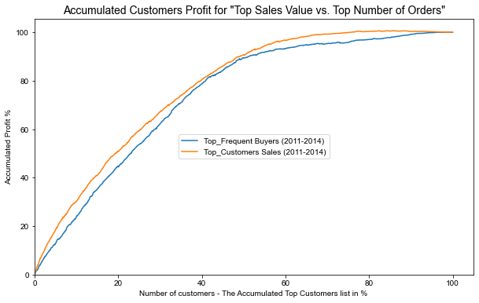

```python
plt.figure(figsize = [10, 6])
plt.errorbar(x=Lst_113_cumu['Accum_Customers(%)'], y=Lst_113_cumu['Accum_Profit(%)'], label = 'Top_Frequent Buyers (2011-2014)')
plt.errorbar(x=Lst_223_cumu['Accum_Customers(%)'], y=Lst_223_cumu['Accum_Profit(%)'], label = 'Top_Customers Sales (2011-2014)')
plt.ylabel('Accumulated Profit %')
plt.xlabel('Number of customers - The Accumulated Top Customers list in % ')
plt.ylim(0)
plt.xlim(0)
plt.title('Accumulated Customers Profit for "Top Sales Value vs. Top Number of Orders"', fontsize = 14)
plt.legend(loc = 'center')
sb.set_style('whitegrid');
```

In this customer list, Top profitable customers should be taken from Top Sales Value, not Top number of Orders.

### Customers Yearly Analysis

Further analysis on Top Customers' Sales list *based on four periods of four years*. This means that we have a seasonality, and the yearly constructed table is the mean of the four seasons. The table will contain number of rows equal to number of customers.

#### Preparing a yearly customers' list with their profit, number of orders, sales value, segment type.

```python
#Preparing customers' list with the following variables
df_custa = df[['Customer_ID','Order_Year','Sales_USD', 'Profit_USD', 'Counts']].groupby(['Customer_ID', 'Order_Year']).sum()
df_custb = df[['Customer_ID','Order_Year']].groupby(['Customer_ID', 'Order_Year']).count()
df_custc = df[['Customer_ID','Order_Year','Segment']].groupby(['Customer_ID', 'Order_Year']).first()
df_custd = pd.merge(left=df_custa, right=df_custb, how='left', left_index=True, right_index=True)

df_cust3 = pd.merge(left=df_custc, right=df_custd, how='left', left_index=True, right_index=True)
df_cust3.rename(columns ={'Counts':'Orders'}, inplace = True)

# Reorder columns
trans = df_cust3['Orders']
profit = df_cust3['Profit_USD']
df_cust3.drop(['Orders'], axis=1,inplace = True)
df_cust3.drop(['Profit_USD'], axis=1,inplace = True)
df_cust3.insert(loc = 1, column='Orders', value = trans)
df_cust3.insert(loc = 0, column='Profit_USD', value = profit)
df_cust3.head()
```

| Customer_ID | Order_Year | Profit_USD | Segment | Orders | Sales_USD |
| --- | --- | --- | --- | --- | --- |
| AA-10315 | 2011 | 319.2335 | Consumer | 12 | 1732.2965 |
|  | 2012 | 34.0996 | Consumer | 2 | 2740.3700 |
|  | 2013 | -439.8641 | Consumer | 11 | 5385.5400 |
|  | 2014 | 534.2215 | Consumer | 17 | 3889.2065 |
| AA-10375 | 2011 | 106.0539 | Consumer | 4 | 752.8820 |

```python
#Filtering the list according to "Customers Top Sales Value" defined earlier with (x%, y%)
#=========================================================================================

print('\n')
print(colored('x ={}%, y ={}%'
              .format(int(x*100), int(y3*100)), 'blue', attrs =['bold']))
df_cust3_G15_inv = df_cust3.drop(df_grp_cust_top.index)
df_cust3_G15 = df_cust3.drop(df_cust3_G15_inv.index)
df_cust3_G15  # This list is filtered according to earlier value of (x&y)
```

```
x =100%, y =100%
```

| Customer_ID | Order_Year | Profit_USD | Segment | Orders | Sales_USD |
| --- | --- | --- | --- | --- | --- |
| AA-10315 | 2011 | 319.2335 | Consumer | 12 | 1732.2965 |
|  | 2012 | 34.0996 | Consumer | 2 | 2740.3700 |
|  | 2013 | -439.8641 | Consumer | 11 | 5385.5400 |
|  | 2014 | 534.2215 | Consumer | 17 | 3889.2065 |
| AA-10375 | 2011 | 106.0539 | Consumer | 4 | 752.8820 |
| ... | ... | ... | ... | ... | ... |
| ZD-11925 | 2014 | 241.9800 | Consumer | 8 | 856.2600 |
| ZD-21925 | 2011 | -673.7706 | Consumer | 13 | 2201.0420 |
|  | 2012 | -44.6605 | Consumer | 11 | 3188.2995 |
|  | 2013 | 215.3845 | Consumer | 6 | 2060.0640 |
|  | 2014 | 226.3677 | Consumer | 6 | 2029.9389 |

5651 rows × 4 columns

*Customers' yearly average profit, sales, orders (transactions)*

> Ranking customers for profitability will be measured/based on yearly aggregated orders.

```python
# Customer yearly MEAN Sales, Profit, Order number. Then sort "Profit" in descending order
# This list is filtered according to "Customers Top Sales Value" defined earlier with (x%, y%)
#============================================================================================

print('\n')
print(colored('x ={}%, y ={}%'
              .format(int(x*100), int(y3*100)), 'blue', attrs =['bold']))

df_cust4_G15 = df_cust3_G15.groupby(['Customer_ID'])['Segment'].first()
df_cust8_G15 = df_cust3_G15.groupby(['Customer_ID']).mean()

df_cust5_G15 = pd.merge(left=df_cust4_G15, right=df_cust8_G15, how='left', left_index=True, right_index=True)

df_cust5_G15 = df_cust5_G15.sort_values(['Profit_USD'], axis=0, ascending = False)
df_cust5_G15
```

```
x =100%, y =100%
```

| Customer_ID | Segment | Profit_USD | Orders | Sales_USD |
| --- | --- | --- | --- | --- |
| TC-20980 | Corporate | 2196.868725 | 14.75 | 8554.567250 |
| RB-19360 | Consumer | 2130.987875 | 16.25 | 7299.408650 |
| SC-20095 | Consumer | 2026.554475 | 13.25 | 6400.652500 |
| BE-11335 | Home Office | 1947.674075 | 23.50 | 6789.504600 |
| HL-15040 | Consumer | 1914.375445 | 11.75 | 7416.057645 |
| ... | ... | ... | ... | ... |
| GT-14635 | Corporate | -947.520765 | 9.75 | 4770.086960 |
| KD-6270 | Consumer | -1023.540000 | 2.00 | 813.060000 |
| TC-11535 | Home Office | -1355.658000 | 10.00 | 2214.972000 |
| CS-12505 | Consumer | -1609.342025 | 7.50 | 2883.811600 |
| DM-3345 | Corporate | -1824.870000 | 4.00 | 1666.140000 |

1590 rows × 4 columns

```python
#Removing customers with negative profit since our interest to study the profitability (not loss)
df_cust5_G15p = df_cust5_G15.query('Profit_USD > 0')
df_cust5_G15p.tail(3)
```

| Customer_ID | Segment | Profit_USD | Orders | Sales_USD |
| --- | --- | --- | --- | --- |
| KH-6690 | Corporate | 1.028 | 4.0 | 565.338 |
| LH-6900 | Consumer | 0.664 | 1.0 | 280.264 |
| EA-4035 | Corporate | 0.444 | 1.5 | 65.904 |

### Correlation between Average Customer number of Orders & Profit

|  | Orders | Profit_USD |
| --- | --- | --- |
| Orders | 1.00000 | 0.61475 |
| Profit_USD | 0.61475 | 1.00000 |

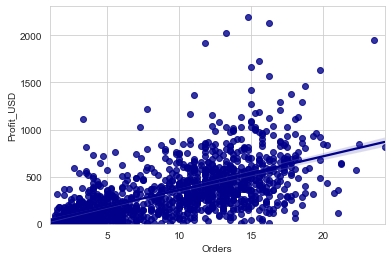

```python
sb.regplot(x="Orders", y="Profit_USD", data=df_cust5_G15p, color='darkblue')
plt.ylim(0,)
df_cust5_G15p[['Orders','Profit_USD']].corr()
```

|  | Orders | Profit_USD |
| --- | --- | --- |
| Orders | 1.00000 | 0.61475 |
| Profit_USD | 0.61475 | 1.00000 |

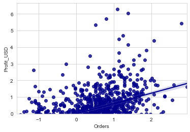

```python
#Removing the first column "Segment" then pandas dataframe
df_cust5_G15ps = df_cust5_G15p.values[:,1:]

# normalizing the data with sklearn
from sklearn.preprocessing import StandardScaler
df_cust5_G15ps = StandardScaler().fit_transform(df_cust5_G15ps)
df_cust5_G15ps = pd.DataFrame(df_cust5_G15ps)
df_cust5_G15ps.rename(columns ={0:'Profit_USD',1:'Orders',2:'Sales_USD'}, inplace = True)

sb.regplot(x="Orders", y="Profit_USD", data=df_cust5_G15ps, color='darkblue')
plt.ylim(0,)

df_cust5_G15ps[['Orders','Profit_USD']].corr()
```

Both the correlation value and the plot (before & after the normalization) are the same

## Correlation between Customer Sales & Profit

```python
# I will perform manual way for normalization

#generating copy

df_cust5_G15ps2 = df_cust5_G15p.groupby('Customer_ID').first()
df_cust5_G15ps2 = df_cust5_G15ps2.sort_values(['Profit_USD'], axis=0, ascending = False)

#Performing normalization

p_max = df_cust5_G15ps2.Profit_USD.max()
s_max = df_cust5_G15ps2.Sales_USD.max()
t_max = df_cust5_G15ps2.Orders.max()

df_cust5_G15ps2['Profit_USD'] = df_cust5_G15ps2['Profit_USD']/p_max
df_cust5_G15ps2['Sales_USD'] = df_cust5_G15ps2['Sales_USD']/s_max
df_cust5_G15ps2['Orders'] = df_cust5_G15ps2['Orders']/t_max

df_cust5_G15ps2.head(3)
```

| Customer_ID | Segment | Profit_USD | Orders | Sales_USD |
| --- | --- | --- | --- | --- |
| TC-20980 | Corporate | 1.000000 | 0.608247 | 0.959352 |
| RB-19360 | Consumer | 0.970011 | 0.670103 | 0.818592 |
| SC-20095 | Consumer | 0.922474 | 0.546392 | 0.717801 |

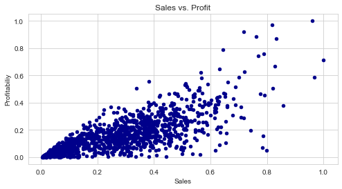

|  | Sales_USD | Profit_USD |
| --- | --- | --- |
| Sales_USD | 1.000000 | 0.776122 |
| Profit_USD | 0.776122 | 1.000000 |

```python
#Drawing the relationship between number of orders vs. profitablity

df_cust5_G15ps2.plot(kind='scatter', x='Sales_USD', y='Profit_USD', figsize=(8, 4), color='darkblue')
plt.title('Sales vs. Profit')
plt.xlabel('Sales')
plt.ylabel('Profitabiliy')
plt.show()

df_cust5_G15ps2[['Sales_USD','Profit_USD']].corr()
```

The correlation is stronger than number of orders where the correlation = 0.77

```python
df['Ship_Mode'].dtypes
```

```
CategoricalDtype(categories=['Standard Class', 'Second Class', 'First Class', 'Same Day'], ordered=True)
```

## How the number of orders are split between Ship_Mode & Segment

The bar chart shows that Consumers' orders are the highest compared other segments. However the number of orders decreases with the change of shipping mode. So the largest difference between segments exists in standard_class while lowest difference exists in same_day shipping mode.

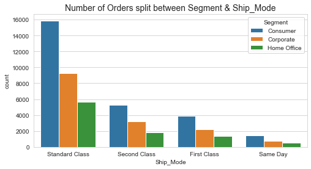

```python
plt.figure(figsize = [8, 4])
shipmode_class = ['Standard Class', 'Second Class', 'First Class', 'Same Day']
ship_cat = pd.api.types.CategoricalDtype(ordered=True, categories = shipmode_class)
df['Ship_Mode'] = df['Ship_Mode'].astype(ship_cat);
plt.title("Number of Orders split between Segment & Ship_Mode", fontsize = 14)
sb.countplot(data = df, x = 'Ship_Mode', hue = 'Segment');
```

The bar chart shows that Consumer Segment & Standard_Class shipping mode orders are the highest.

### Did you observe any interesting relationships between the other features (not the main feature(s) of interest)?

Valuable customers (profitable one) are not always the customers with higher number of transactions (orders). Therefore, customers with less number of orders can contribute more to the total profit than others with top frequent sales transactions (orders). This has been seen in the S-curve of profitability.

## Multivariate Exploration

*I need to work on a group of variables "Sales, Orders, Segment, Ship_Mode" to see how it affect the profitability when work together*

##### At the end, use A/B Test to support your answer to any of the questions raised earlier

I will construct a table with number of rows equal to number of customers over *single period of 4 years*. Each record contains sales value, segment, shipping mode, profit, number of orders

```python
df.dtypes
```

```
Row_ID                     int64
Order_Year                 int64
Order_Month                int64
Order_ID                  object
WaitTime_Days              int64
Order_Date        datetime64[ns]
Ship_Date         datetime64[ns]
Ship_Mode               category
Customer_ID               object
Customer_Name             object
Segment                 category
City                      object
State                     object
Country                   object
Market                    object
Region                    object
Product_ID                object
Category                  object
Sub-Category              object
Product_Name              object
Sales_USD                float64
Quantity                   int64
Discount                 float64
Profit_USD               float64
Ship_Cost_USD            float64
Order_Priority            object
Counts                     int64
dtype: object
```

```python
#Converting categorical variable into dummy variables
segment_dummies = pd.get_dummies(df['Segment'], dtype=int)
shipmode_dummies = pd.get_dummies(df['Ship_Mode'], dtype=int)

df_new = df.join(segment_dummies)
df_new = df_new.join(shipmode_dummies)

# Rename column label (replace "space" with "_")
df_new.columns = df_new.columns.str.replace(' ', '_')
df_new.columns
```

```
Index(['Row_ID', 'Order_Year', 'Order_Month', 'Order_ID', 'WaitTime_Days',
       'Order_Date', 'Ship_Date', 'Ship_Mode', 'Customer_ID', 'Customer_Name',
       'Segment', 'City', 'State', 'Country', 'Market', 'Region', 'Product_ID',
       'Category', 'Sub-Category', 'Product_Name', 'Sales_USD', 'Quantity',
       'Discount', 'Profit_USD', 'Ship_Cost_USD', 'Order_Priority', 'Counts',
       'Consumer', 'Corporate', 'Home_Office', 'Standard_Class',
       'Second_Class', 'First_Class', 'Same_Day'],
      dtype='object')
```

```python
df_new_group_a = df_new.groupby(['Customer_ID']).sum()
df_new_group_b = df_new.groupby(['Customer_ID'])['Segment'].first()

df_new_group = df_new_group_a.join(df_new_group_b)

df_new_group = df_new_group.sort_values(['Sales_USD'], axis=0, ascending = False)
df_new_group = df_new_group.rename(columns={'Counts':'Orders'})

df_new_group.head(3)
```

| Customer_ID | Row_ID | Order_Year | Order_Month | WaitTime_Days | Sales_USD | Quantity | Discount | Profit_USD | Ship_Cost_USD | Orders | Consumer | Corporate | Home_Office | Standard_Class | Second_Class | First_Class | Same_Day | Segment |
| --- | --- | --- | --- | --- | --- | --- | --- | --- | --- | --- | --- | --- | --- | --- | --- | --- | --- | --- |
| TA-21385 | 1161514 | 130831 | 523 | 259 | 35668.12080 | 239 | 5.210 | 6274.98910 | 2449.87 | 65 | 0 | 0 | 65 | 38 | 17 | 8 | 2 | Home Office |
| GT-14710 | 1769674 | 148946 | 589 | 319 | 34471.89028 | 284 | 8.806 | 5164.84718 | 2906.22 | 74 | 74 | 0 | 0 | 51 | 10 | 12 | 1 | Consumer |
| TC-20980 | 1074794 | 118748 | 485 | 266 | 34218.26900 | 209 | 6.552 | 8787.47490 | 2020.81 | 59 | 0 | 59 | 0 | 45 | 4 | 9 | 1 | Corporate |

```python
variable1 = ['Profit_USD', 'Orders', 'Standard_Class', 'Second_Class', 'First_Class', 'Same_Day']
variable2 = ['Profit_USD', 'Orders', 'Consumer', 'Corporate', 'Home_Office']
variable3 = ['Profit_USD','Consumer', 'Corporate', 'Home_Office', 'Standard_Class', 'Second_Class', 'First_Class', 'Same_Day']
```

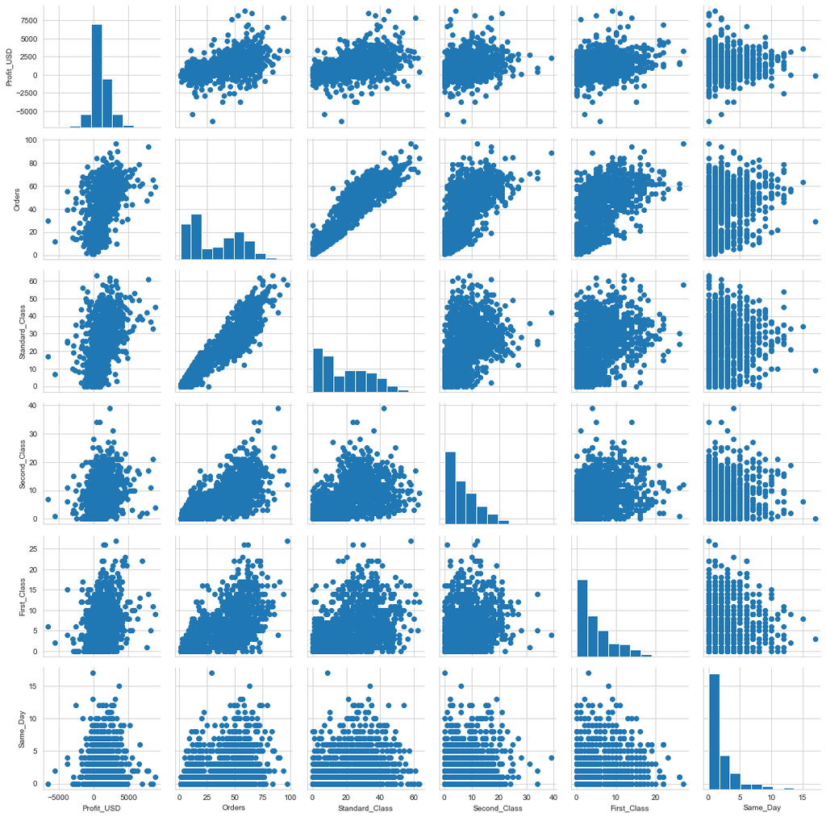

```python
#Interrogating the relationship between profit & shipping modes
diag1 = sb.PairGrid(data = df_new_group, vars = variable1)
diag1.map_diag(plt.hist)
diag1.map_offdiag(plt.scatter);
```

- From the plot, Standard_Class has the highest number of customers with the highest number of orders associated to highest profit and consequently to the overall profit. Second_Class comes next in number of customers with the higher number of orders, then First_Class, and last the Same_Day.
- The highest number of customers with low number of orders associated to low profit and consequently to the overall profit comes from Second_Class.

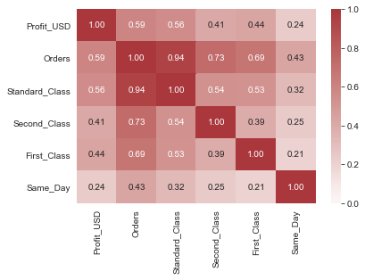

```python
sb.heatmap(df_new_group[variable1].corr(), annot = True, fmt = '.2f',
           cmap = 'vlag', center = 0, vmin =0);
```

The change in number of orders is strongly correlated with profit in Standard_Class, next comes First_Class, then Second_Class, and last Same_Day

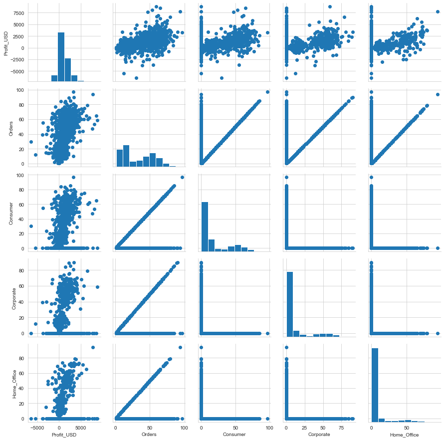

```python
#Interrogating the relationship between profit & segment
diag2 = sb.PairGrid(data = df_new_group, vars = variable2)
diag2.map_diag(plt.hist)
diag2.map_offdiag(plt.scatter);
```

It is clear only that Consumer segment has the highest number of customers with the highest number of orders associated to high profit

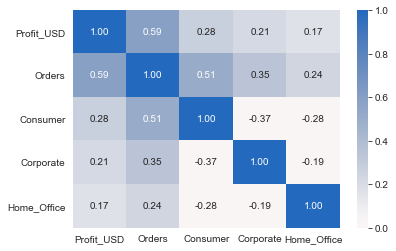

```python
sb.heatmap(df_new_group[variable2].corr(), annot = True, fmt = '.2f',
           cmap = 'vlag_r', center = 0, vmin =0);
```

The change in number of orders in each segment is not strongly correlated to the change in profit.

## Customer's Orders vs. Customer Segment

"Consumer" segment has large number of customers with:

- Highest number of profitable customers ( >2.5k USD).
- Highest number of customers who ordered (60-80) sales order
- Highest number of customers with loss (negative profit)

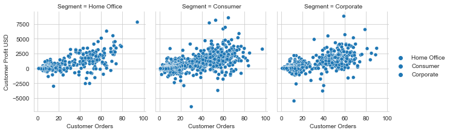

```python
diag3 = sb.FacetGrid(df_new_group, col="Segment")
diag3.map_dataframe(sb.scatterplot, x="Orders", y="Profit_USD", hue="Segment")
diag3.set_axis_labels("Customer Orders", "Customer Profit USD")
diag3.add_legend();
```

Existing number of Customers distribute in almost a uniform way with number of transaction over the four years. Corporate & Home Office have some gap between 20-40 transaction over the time period (2011-2014)

## Customers' Sales vs. Profit vs. number of Orders

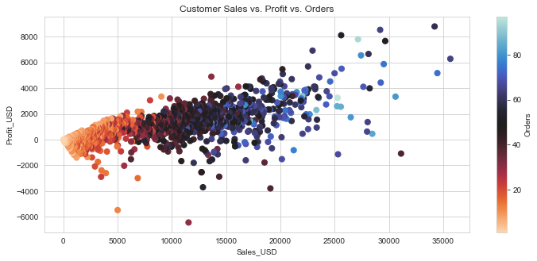

```python
#Distribution of customers with their Sales, Profit, number of Orders

plt.figure(figsize = [12,5])
plt.scatter(data = df_new_group, x = 'Sales_USD', y = 'Profit_USD', c = 'Orders',
            cmap = 'icefire_r',
            s = 50,
            )
plt.title('Customer Sales vs. Profit vs. Orders')
plt.xlabel("Sales_USD")
plt.ylabel("Profit_USD")

plt.colorbar(label='Orders');
```

The top frequent buyers are not the same as the top profitable buyers!

## Customer Profit vs Segment

Weak segment correlation (0.17 - 0.28) with Profit.

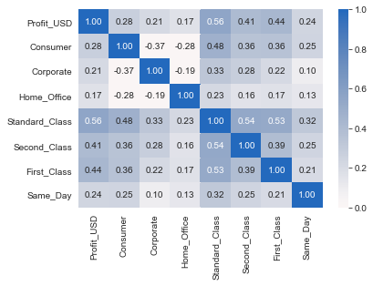

```python
sb.heatmap(df_new_group[variable3].corr(), annot = True, fmt = '.2f',
           cmap = 'vlag_r', center = 0, vmin =0);
```

Top profitable customers, are those from Consumer segment (corr = 0.28) with Standard_Class shipping mode (corr = 0.56). That confirms what we see in Bivarite exploration.

## Statistical proof for Profit correlation with Segment

### A/B Test: Customer Segmentation

1. Developing two separate tables with equal samples one for Consumer & the other for Corporate Segment
2. Draw the Null-Hypothesis distribution for Consumer Segment using Mean_Consumer_mean & Std_Corporate, using 10k repeated test for mean & std calculation
3. Locating the the Mean_Corporate on the Null-Hypothesis dist.

### Hypothesis

1. H0, Null Hypothesis: Corporate Segment customers is same as the Consumer Segment or worse in *profit*
2. H1, Alternative Hypothesis: Corporate Segment customers is *profitable* than Consumer Segment.
3. This is Right-Tailed test

$$H_0: \mu_{Corporate} - \mu_{Consumer} \leq 0$$

$$H_1: \mu_{Corporate} - \mu_{Consumer} > 0$$

```python
print("Number of Segment 'Consumers' in the sample = ", df_new_group.query('Segment == "Consumer"').count()[0])
print("Number of Segment 'Corporate' in the sample = ", df_new_group.query('Segment == "Corporate"').count()[0])
print("Number of Segment 'Home Office' in the sample = ", df_new_group.query('Segment == "Home Office"').count()[0])
```

```
Number of Segment 'Consumers' in the sample =  818
Number of Segment 'Corporate' in the sample =  476
Number of Segment 'Home Office' in the sample =  296
```

```python
df_new_group.head()
```

| Customer_ID | Row_ID | Order_Year | Order_Month | WaitTime_Days | Sales_USD | Quantity | Discount | Profit_USD | Ship_Cost_USD | Orders | Consumer | Corporate | Home_Office | Standard_Class | Second_Class | First_Class | Same_Day | Segment |
| --- | --- | --- | --- | --- | --- | --- | --- | --- | --- | --- | --- | --- | --- | --- | --- | --- | --- | --- |
| TA-21385 | 1161514 | 130831 | 523 | 259 | 35668.12080 | 239 | 5.210 | 6274.98910 | 2449.87 | 65 | 0 | 0 | 65 | 38 | 17 | 8 | 2 | Home Office |
| GT-14710 | 1769674 | 148946 | 589 | 319 | 34471.89028 | 284 | 8.806 | 5164.84718 | 2906.22 | 74 | 74 | 0 | 0 | 51 | 10 | 12 | 1 | Consumer |
| TC-20980 | 1074794 | 118748 | 485 | 266 | 34218.26900 | 209 | 6.552 | 8787.47490 | 2020.81 | 59 | 0 | 59 | 0 | 45 | 4 | 9 | 1 | Corporate |
| SM-20320 | 839344 | 78493 | 287 | 178 | 31125.29496 | 139 | 7.012 | -1083.67434 | 944.39 | 39 | 0 | 0 | 39 | 30 | 6 | 2 | 1 | Home Office |
| BW-11110 | 1887120 | 163027 | 486 | 322 | 30613.61650 | 316 | 9.280 | 3337.46590 | 3121.40 | 81 | 0 | 81 | 0 | 48 | 15 | 11 | 7 | Corporate |

```python
df_new3_Consumer = df_new_group.query('Segment == "Consumer"')
df_new3_Corporate = df_new_group.query('Segment == "Corporate"')
df_new3_Home = df_new_group.query('Segment == "Home Office"')
```

```python
#Developing Mean & Std for Corporate Segment

df_new3_Corporate_296_mean = []

for _ in range(10000):
    df_new3_Corporate_296 = df_new3_Corporate.sample(296, replace = True)
    df_new3_Corporate_296 = df_new3_Corporate_296.Profit_USD.mean()
    df_new3_Corporate_296_mean.append(df_new3_Corporate_296)


std_sampling_dist_Corporate = np.std(df_new3_Corporate_296_mean)
mean_sampling_dist_Corporate = np.mean(df_new3_Corporate_296_mean)
print("std_sampling_dist_Corporate = ", std_sampling_dist_Corporate)# the standard deviation of the sampling distribution
print("mean_sampling_dist_Corporate = ", mean_sampling_dist_Corporate)
```

```
std_sampling_dist_Corporate =  78.7436365412184
mean_sampling_dist_Corporate =  928.2747843221687
```

```
mean_sampling_dist_Consumer =  915.6122990592635
```

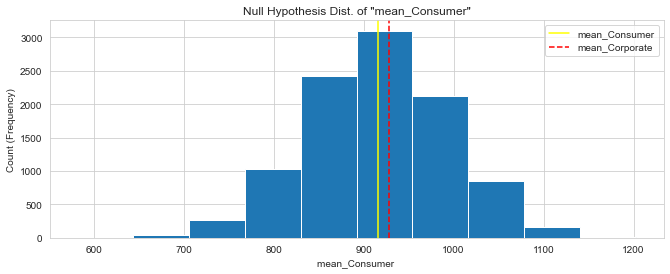

```python
#Developing the Mean for Consumer Segment

df_new3_Consumer_296_mean = []

for _ in range(10000):
    df_new3_Consumer_296 = df_new3_Consumer.sample(296, replace = True)
    df_new3_Consumer_296 = df_new3_Consumer_296.Profit_USD.mean()
    df_new3_Consumer_296_mean.append(df_new3_Consumer_296)


mean_sampling_dist_Consumer = np.mean(df_new3_Consumer_296_mean)
print("mean_sampling_dist_Consumer = ", mean_sampling_dist_Consumer)

#Drawing Null Hypothesis dis. for the Consumer Segment & locating the Corporate Segment mean on the Null Hypothesis
null_mean = mean_sampling_dist_Consumer # mean profitable (valuable) for consumer segment
null_vals = np.random.normal(null_mean, std_sampling_dist_Corporate , 10000)


plt.figure(figsize=(11,4))
plt.hist(null_vals)
plt.axvline(mean_sampling_dist_Consumer,color='yellow', label = 'mean_Consumer')
plt.axvline(x=mean_sampling_dist_Corporate, color = 'red', linestyle ='dashed', label = 'mean_Corporate')
plt.title('Null Hypothesis Dist. of "mean_Consumer"')
plt.xlabel('mean_Consumer ')
plt.ylabel('Count (Frequency)')
plt.legend();
```

```python
# Calculating P value for the Null
(null_vals > mean_sampling_dist_Corporate).mean()
```

```
0.4443
```

1. p-value is greater than alpha (0.05) therefore we cannot Reject NULL Hypothesis.
2. Corporate segment customer is not more valuable (profitable) than Consumer segment customer
3. From the fig, it is obvious that the mean_Corporate falls in Null Hypothesis Distribution (Consumer Segment)

### A/B Test: Alternative Solution Method 2 (using Confidence Interval)

1. H0, Null Hypothesis: Corporate Segment customers is same as the Consumer Segmente in profit.
2. H1, Alternative Hypothesis: Corporate Segment customers is not same as Consumer Segment profit.
3. This is two-tailed test

$$H_0: \mu_{Corporate} = \mu_{Consumer} $$

$$H_1: \mu_{Corporate} \neq \mu_{Consumer} $$

```python
#Developing the Null Hypothesis distribution (Mean distribution for Consumer Segment)

df_new3_Consumer_10000_mean = []

for _ in range(10000):
    df_new3_Consumer_10000 = df_new3_Consumer.sample(10000, replace = True)
    df_new3_Consumer_10000 = df_new3_Consumer_10000.Profit_USD.mean()
    df_new3_Consumer_10000_mean.append(df_new3_Consumer_10000)
```

```python
# Calculating the upper & lower bounds for the confidence interval with with alpha = 0.05

null_vals_new = df_new3_Consumer_10000_mean
upper_bound = np.percentile(null_vals_new,(100-5/2))
lower_bound = np.percentile(null_vals_new,(5/2))
```

```python
mean_null_Consumer = np.mean(df_new3_Consumer_10000_mean)
print("mean_null_Consumer = ", mean_null_Consumer)
```

```
mean_null_Consumer =  916.0114472625257
```

```python
#Developing the Mean & Std for hypothesid test (Corporate Segment)

df_new3_Corporate_10000_mean = []

for _ in range(10000):
    df_new3_Corporate_10000 = df_new3_Corporate.sample(10000, replace = True)
    df_new3_Corporate_10000 = df_new3_Corporate_10000.Profit_USD.mean()
    df_new3_Corporate_10000_mean.append(df_new3_Corporate_10000)
```

```python
std_sampling_dist_Corporate_new = np.std(df_new3_Corporate_10000_mean)
mean_sampling_dist_Corporate_new = np.mean(df_new3_Corporate_10000_mean)
print("std_sampling_dist_Corporate_new = ", std_sampling_dist_Corporate_new)# the standard deviation of the sampling distribution
print("mean_sampling_dist_Corporate = ", mean_sampling_dist_Corporate_new)
```

```
std_sampling_dist_Corporate_new =  13.471509291077366
mean_sampling_dist_Corporate =  926.9520283244311
```

```
(889.8156720652499, 941.3779168686472, 916.0114472625257, 928.2747843221687)
```

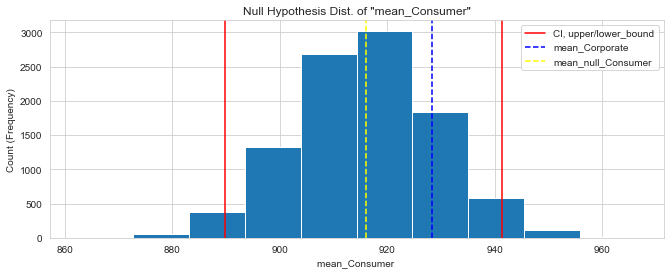

```python
plt.figure(figsize=(11,4))
plt.hist(null_vals_new)
plt.axvline(upper_bound,color='red', label = 'CI, upper/lower_bound')
plt.axvline(lower_bound, color = 'red')
plt.axvline(mean_sampling_dist_Corporate, color = 'blue', linestyle = 'dashed', label ='mean_Corporate')
plt.axvline(mean_null_Consumer, color = 'yellow', linestyle = 'dashed', label ='mean_null_Consumer')
plt.title('Null Hypothesis Dist. of "mean_Consumer"')
plt.xlabel('mean_Consumer ')
plt.ylabel('Count (Frequency)')
plt.legend()

(lower_bound, upper_bound, mean_null_Consumer, mean_sampling_dist_Corporate)
```

```python
Mean_Difference = abs(mean_null_Consumer - mean_sampling_dist_Corporate)
Mean_Difference
```

```
12.263337059642936
```

```python
LH = mean_null_Consumer - Mean_Difference
RH = mean_null_Consumer + Mean_Difference
(LH, RH)
```

```
(903.7481102028828, 928.2747843221687)
```

```python
p_value_LH = (null_vals_new < LH).mean()
p_value_RH = (null_vals_new > RH).mean()
p_value = p_value_LH + p_value_RH
print('p_value_LH = {}, p_value_RH = {}, p_value = {}'.format(p_value_LH, p_value_RH, p_value))
```

```
p_value_LH = 0.1717, p_value_RH = 0.1748, p_value = 0.34650000000000003
```

1. p-value is greater than alpha (0.05) therefore we cannot Reject NULL Hypothesis.
2. From the fig, it is obvious that "stats_diff_mean" falls in Null Hypothesis Distribution (mean_diffs)
3. Corporate_mean (obs_diff_mean) has same valuable (profitable) customers as Consumer_mean segment

### Talk about some of the relationships you observed in this part of the investigation. Were there features that strengthened each other in terms of looking at your feature(s) of interest?

- Number of Customer vs. Ship_Mode: The strongest correlation goes to Standard_Class
- Ship_Mode vs. Profit: Standard_Class contributes the most among for overall profit compared to other shipping modes. Second_Class has the highest number of customer with low profit. Same_Day has customers with the weakest correlation with profit
- Segment vs. Profit: Not a strong indicator for profit, however Consumer segmement has cutomers with better association with profit than Corporate and Home_Office.

### Were there any interesting or surprising interactions between features?

Not exactly surprising, but at aglance you may think that Corporate segment is profitable than Consumer. But after detailed analysis with visualization and support of A/B Test, it clearly that the customer profit is coming from the same Consumer profit distribution.

```python
!jupyter nbconvert Presentation_ValuableCust_YSR.ipynb --to slides --no-input
```